# Moar Stimuli

March 26, 2018

## Exercise

- Using [list](https://docs.python.org/2/tutorial/datastructures.html) to store the result

```python
result = [] # setup an empty list to store the result
for i in range(setsize):
    stim = psychopy.visual.TextStim(window, text = stimuli[i])
    stim.draw()
    ...
    ...
    result.append(response[0]) #attach the response to the end of the list
    # result.append((response[0], reaction_time)) # appending a tuples
```

## Stimuli

- There are many other [stock stimuli](http://www.psychopy.org/api/visual.html) in PsychoPy.
- Today is about [shapes](http://www.psychopy.org/api/visual/shapestim.html#psychopy.visual.ShapeStim).
- However, let's look at Window first.

## Window

- Originally, window is setup like this:

```python
window = psychopy.visual.Window()
```

- However, I typically open the window as:

```python
window = visual.Window(
    units = 'height',
    fullscr=True,
    color = (200, 200, 200),
    colorSpace = 'rgb255',
    winType = 'pyglet',
    screen = 0
)
```

- What does those mean?
- See code: open_window.py

## Units

- [Units for the window and stimuli](http://www.psychopy.org/general/units.html#units)
- Pixels
- Height units
  - One unit is equal to screen height.
- Normalized units
  - Both x and y axis are scaled to 1.
  - Totally screw up drawing circles.

## Coordinate System

Unlike the traditional computer coordinate system:

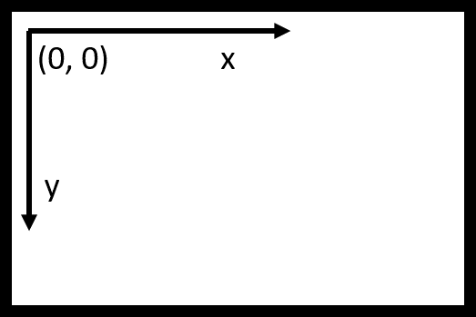

PsychoPy uses coordinate system like this:

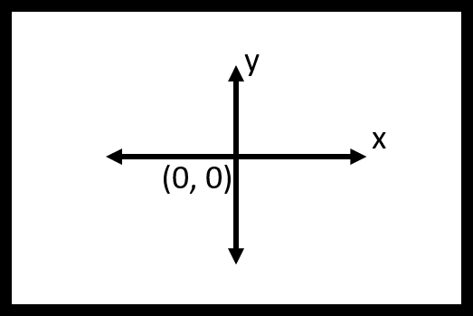

## Drawing Empty Frames

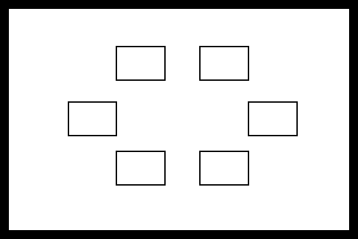

## Drawing Empty Frames

- Drawing one frame
- Rect

```python
rect = psychopy.visual.Rect(window, width = 0.2, height = 0.2)
rect.draw()
```

- Tuning more [knobs](http://www.psychopy.org/api/visual/shapestim.html#psychopy.visual.ShapeStim)

```python
rect = psychopy.visual.Rect(
    window,
    width = 0.2,
    height = 0.2,
    lineWidth = 5, # yes, 5.
    lineColor = (0, 0, 0),
    lineColorSpace = 'rgb255',
    fillColor = None
)
```

## Drawing Empty Frames

- Predefine the frame positions.
- Draw multiple frames one by one.
- Rect3.py

## Mouse Clicks

- Mouse
- isPressedIn
- Rect_Mouse.py

## ShapeStim

- It has a lot of hidden options, e.g.:
  - Orientate stimulus. See: Rect_Mouse_Orientation.py
  - Drawing irregular shape stimulus. See: Colorwheel.py

## Exercise

- 6 seqares on the screen.
  - five of them rotating at the same direction
  - one of them rotating at the opposite direction
- Participants have to click on the square rotating at the wrong direction
- Record RT and correctness.
- Bonus points:
  - Change the orientation speed
  - Change the size of the item
  - Change the shape from square to rectangle